# HW11

Sean Fahey

2023-03-22

```r
library(car)
library(ggfortify)
library(MuMIn)
```

# In-Class

```r
birdmass = read.csv("~/Downloads/offspring_mass.csv", header=TRUE)
birdmass$plant = as.factor(birdmass$plant)

head(birdmass)
```

```
##   offspring_mass dist_edge feedings_per_day canopy_cover height     plant
## 1          30.51      51.3              5.6        0.088   8.86       oak
## 2          28.07      70.1              5.0        0.532   0.20       oak
## 3          25.46      49.1              3.1        0.308   4.01     maple
## 4          31.52      17.4              5.6        0.658   4.91 raspberry
## 5          29.24      50.8              5.1        0.807   3.41       oak
## 6          28.24      71.6              5.1        0.255   0.25       oak
```

### One model at a time for now

Fit a linear model (lm) of offspring_mass against all of the other variables at once, no interactions. Verify the IVs are not highly correlated, and examine the residuals to assess model assumptions.

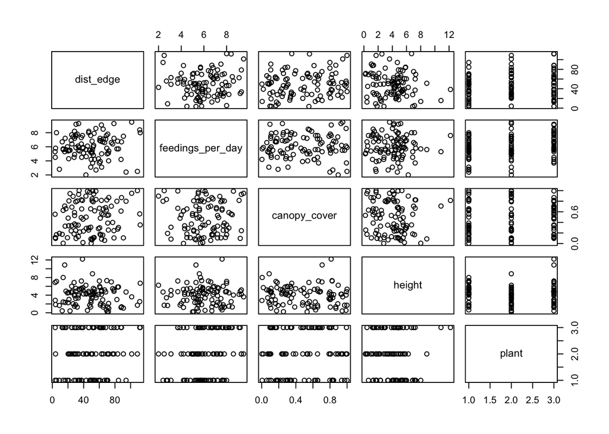

```r
lm.all_no_interactions = lm(
  offspring_mass ~
    dist_edge +
    feedings_per_day +
    canopy_cover +
    height +
    plant,
  data=birdmass
  )

pairs(~dist_edge +
        feedings_per_day +
        canopy_cover +
        height +
        plant,
      data=birdmass
    )
```

```r
vif(lm.all_no_interactions)
```

```
##                      GVIF Df GVIF^(1/(2*Df))
## dist_edge        1.050977  1        1.025172
## feedings_per_day 1.064122  1        1.031563
## canopy_cover     1.037816  1        1.018733
## height           1.077884  1        1.038212
## plant            1.145841  2        1.034620
```

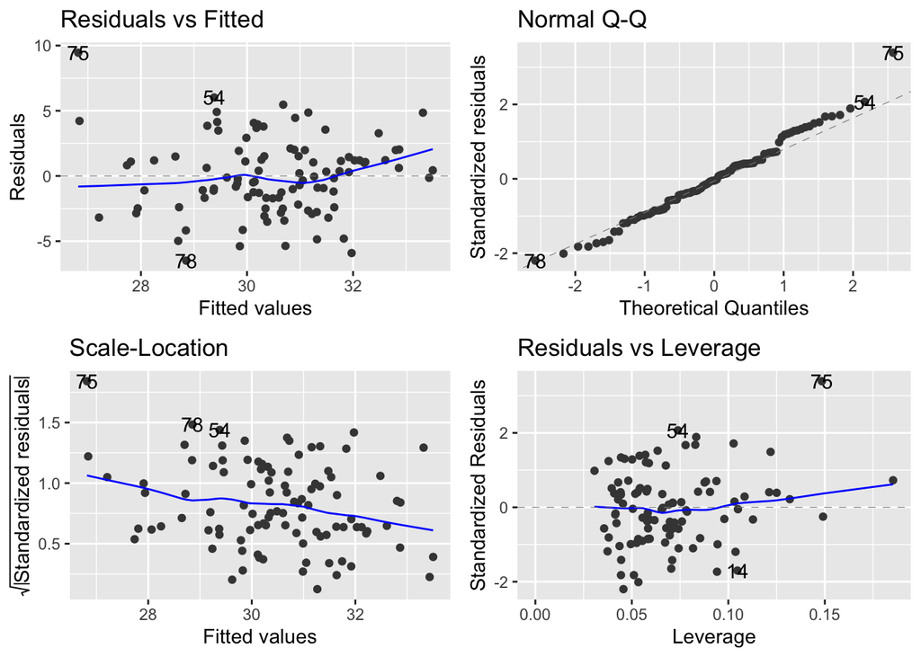

```r
autoplot(lm.all_no_interactions)
```

- Nothing looks super correlated from the ‘pairs’ graph.
- vif (from car library) also shows no strong correlations (no multi-colinearity). GVIF around 1 is fine, 3-5 is not great, >5 is super multi-colinearity.
- Residuals look fine.

Then use summary() to look at the slopes and intercepts.

```r
summary(lm.all_no_interactions)
```

```
##
## Call:
## lm(formula = offspring_mass ~ dist_edge + feedings_per_day +
##     canopy_cover + height + plant, data = birdmass)
##
## Residuals:
##    Min     1Q Median     3Q    Max
## -6.493 -1.836 -0.133  1.515  9.453
##
## Coefficients:
##                  Estimate Std. Error t value Pr(>|t|)
## (Intercept)      25.38379    1.53136  16.576  < 2e-16 ***
## dist_edge        -0.00922    0.01237  -0.745    0.458
## feedings_per_day  0.80658    0.18803   4.290 4.38e-05 ***
## canopy_cover     -0.47252    1.02043  -0.463    0.644
## height            0.16289    0.14056   1.159    0.249
## plantoak          0.61293    0.76338   0.803    0.424
## plantraspberry    0.04362    0.77016   0.057    0.955
## ---
## Signif. codes:  0 '***' 0.001 '**' 0.01 '*' 0.05 '.' 0.1 ' ' 1
##
## Residual standard error: 3.022 on 93 degrees of freedom
## Multiple R-squared:  0.1893, Adjusted R-squared:  0.137
## F-statistic:  3.62 on 6 and 93 DF,  p-value: 0.002852
```

Next fit the same model, but use glm() instead of lm(). Look at the slopes and intercepts of this model.

```r
glm.all_no_interactions = glm(
  offspring_mass ~
    dist_edge +
    feedings_per_day +
    canopy_cover +
    height +
    plant,
  data=birdmass
  )

summary(glm.all_no_interactions)
```

```
##
## Call:
## glm(formula = offspring_mass ~ dist_edge + feedings_per_day +
##     canopy_cover + height + plant, data = birdmass)
##
## Deviance Residuals:
##    Min      1Q  Median      3Q     Max
## -6.493  -1.836  -0.133   1.515   9.453
##
## Coefficients:
##                  Estimate Std. Error t value Pr(>|t|)
## (Intercept)      25.38379    1.53136  16.576  < 2e-16 ***
## dist_edge        -0.00922    0.01237  -0.745    0.458
## feedings_per_day  0.80658    0.18803   4.290 4.38e-05 ***
## canopy_cover     -0.47252    1.02043  -0.463    0.644
## height            0.16289    0.14056   1.159    0.249
## plantoak          0.61293    0.76338   0.803    0.424
## plantraspberry    0.04362    0.77016   0.057    0.955
## ---
## Signif. codes:  0 '***' 0.001 '**' 0.01 '*' 0.05 '.' 0.1 ' ' 1
##
## (Dispersion parameter for gaussian family taken to be 9.131082)
##
##     Null deviance: 1047.50  on 99  degrees of freedom
## Residual deviance:  849.19  on 93  degrees of freedom
## AIC: 513.7
##
## Number of Fisher Scoring iterations: 2
```

coefficients (Estimate) are the same as the lm. But now we have Null deviance, Residual deviance, and AIC table at the bottom.

How can we get the AIC down? Try different models and see if we find a lower AIC value.

drop is a way to compare how the model might be simplified: this reruns the model once per term, dropping one term at a time. Each row is the model AIC and Deviance with that term removed.

```r
drop1(glm.all_no_interactions)
```

```
## Single term deletions
##
## Model:
## offspring_mass ~ dist_edge + feedings_per_day + canopy_cover +
##     height + plant
##                  Df Deviance    AIC
## <none>                849.19 513.70
## dist_edge         1   854.26 512.29
## feedings_per_day  1  1017.21 529.75
## canopy_cover      1   851.15 511.93
## height            1   861.45 513.13
## plant             2   856.56 510.56
```

Dropping plant drops AIC to 510. Dropping feedings_per_day actually makes the model worse (increases AIC to 529). Makes sense, because feedings_per_day was the only IV with good correlation.

```r
glm.no_plant = glm(
  offspring_mass ~
    dist_edge +
    feedings_per_day +
    canopy_cover +
    height,
  data=birdmass
  )

summary(glm.no_plant)
```

```
##
## Call:
## glm(formula = offspring_mass ~ dist_edge + feedings_per_day +
##     canopy_cover + height, data = birdmass)
##
## Deviance Residuals:
##     Min       1Q   Median       3Q      Max
## -6.7186  -2.0335  -0.2562   1.8387   9.6956
##
## Coefficients:
##                   Estimate Std. Error t value Pr(>|t|)
## (Intercept)      25.708167   1.478677  17.386  < 2e-16 ***
## dist_edge        -0.008677   0.012233  -0.709    0.480
## feedings_per_day  0.800564   0.181438   4.412  2.7e-05 ***
## canopy_cover     -0.421840   1.011515  -0.417    0.678
## height            0.134159   0.135985   0.987    0.326
## ---
## Signif. codes:  0 '***' 0.001 '**' 0.01 '*' 0.05 '.' 0.1 ' ' 1
##
## (Dispersion parameter for gaussian family taken to be 9.016375)
##
##     Null deviance: 1047.50  on 99  degrees of freedom
## Residual deviance:  856.56  on 95  degrees of freedom
## AIC: 510.56
##
## Number of Fisher Scoring iterations: 2
```

```r
drop1(glm.no_plant)
```

```
## Single term deletions
##
## Model:
## offspring_mass ~ dist_edge + feedings_per_day + canopy_cover +
##     height
##                  Df Deviance    AIC
## <none>                856.56 510.56
## dist_edge         1   861.09 509.09
## feedings_per_day  1  1032.09 527.21
## canopy_cover      1   858.12 508.75
## height            1   865.33 509.58
```

Let’s drop canopy_cover this time

```r
glm.no_plant_canopy = glm(
  offspring_mass ~
    dist_edge +
    feedings_per_day +
    height,
  data=birdmass
  )

summary(glm.no_plant_canopy)
```

```
##
## Call:
## glm(formula = offspring_mass ~ dist_edge + feedings_per_day +
##     height, data = birdmass)
##
## Deviance Residuals:
##     Min       1Q   Median       3Q      Max
## -6.6225  -2.1328  -0.1859   1.8169   9.5411
##
## Coefficients:
##                   Estimate Std. Error t value Pr(>|t|)
## (Intercept)      25.512063   1.395870  18.277  < 2e-16 ***
## dist_edge        -0.009435   0.012045  -0.783    0.435
## feedings_per_day  0.802057   0.180621   4.441  2.4e-05 ***
## height            0.138765   0.134951   1.028    0.306
## ---
## Signif. codes:  0 '***' 0.001 '**' 0.01 '*' 0.05 '.' 0.1 ' ' 1
##
## (Dispersion parameter for gaussian family taken to be 8.938789)
##
##     Null deviance: 1047.50  on 99  degrees of freedom
## Residual deviance:  858.12  on 96  degrees of freedom
## AIC: 508.75
##
## Number of Fisher Scoring iterations: 2
```

```r
drop1(glm.no_plant_canopy)
```

```
## Single term deletions
##
## Model:
## offspring_mass ~ dist_edge + feedings_per_day + height
##                  Df Deviance    AIC
## <none>                858.12 508.75
## dist_edge         1   863.61 507.38
## feedings_per_day  1  1034.38 525.43
## height            1   867.57 507.84
```

Now let’s drop dist_edge

```r
glm.feedings.height = glm(
  offspring_mass ~
    feedings_per_day +
    height,
  data=birdmass
  )

summary(glm.feedings.height)
```

```
##
## Call:
## glm(formula = offspring_mass ~ feedings_per_day + height, data = birdmass)
##
## Deviance Residuals:
##    Min      1Q  Median      3Q     Max
## -6.731  -2.053  -0.167   1.864   8.980
##
## Coefficients:
##                  Estimate Std. Error t value Pr(>|t|)
## (Intercept)       25.0442     1.2591  19.891  < 2e-16 ***
## feedings_per_day   0.7945     0.1800   4.414 2.64e-05 ***
## height             0.1515     0.1337   1.133     0.26
## ---
## Signif. codes:  0 '***' 0.001 '**' 0.01 '*' 0.05 '.' 0.1 ' ' 1
##
## (Dispersion parameter for gaussian family taken to be 8.903171)
##
##     Null deviance: 1047.50  on 99  degrees of freedom
## Residual deviance:  863.61  on 97  degrees of freedom
## AIC: 507.38
##
## Number of Fisher Scoring iterations: 2
```

```r
drop1(glm.feedings.height)
```

```
## Single term deletions
##
## Model:
## offspring_mass ~ feedings_per_day + height
##                  Df Deviance    AIC
## <none>                863.61 507.38
## feedings_per_day  1  1037.05 523.68
## height            1   875.05 506.70
```

Now drop height:

```r
glm.feedings = glm(
  offspring_mass ~
    feedings_per_day,
  data=birdmass
  )

summary(glm.feedings)
```

```
##
## Call:
## glm(formula = offspring_mass ~ feedings_per_day, data = birdmass)
##
## Deviance Residuals:
##     Min       1Q   Median       3Q      Max
## -6.7185  -2.1339   0.0418   1.7448   8.6174
##
## Coefficients:
##                  Estimate Std. Error t value Pr(>|t|)
## (Intercept)       25.6722     1.1323  22.673  < 2e-16 ***
## feedings_per_day   0.7922     0.1803   4.395 2.81e-05 ***
## ---
## Signif. codes:  0 '***' 0.001 '**' 0.01 '*' 0.05 '.' 0.1 ' ' 1
##
## (Dispersion parameter for gaussian family taken to be 8.929043)
##
##     Null deviance: 1047.50  on 99  degrees of freedom
## Residual deviance:  875.05  on 98  degrees of freedom
## AIC: 506.7
##
## Number of Fisher Scoring iterations: 2
```

```r
drop1(glm.feedings)
```

```
## Single term deletions
##
## Model:
## offspring_mass ~ feedings_per_day
##                  Df Deviance    AIC
## <none>                875.05 506.70
## feedings_per_day  1  1047.50 522.69
```

A note on dropping stuff:

- In the real world, it’s never really worth dropping terms if AIC only improves by 1 or 2. Maybe worth it for > 5, probably worth it for > 10.
- Be careful dropping things for no reason. The data was collected for a reason. Don’t throw out the hypothesis just to get a model that’s slightly better. That’s bad data science.
- Another aproach: start with a simple model and slowly add terms. Go the other direction to arrive at basically the same result.

(“Reverse stepwise”: start with a full model with all the IVs you are considering, and drop them one by one until you get a “good” model.

“Stepwise”: start with a null model (just an intercept) and add potential IVs in until you have a “good” model.)

From the Hajduk dragons blog:

“Generally, if models are within 2 AICc units of each other they are very similar. Within 5 units they are quite similar, over 10 units difference and you can probably be happy with the model with lower AICc. As with p-values though, there is no “hard line” that’s always correct.

### Model averaging

1. Make a model for every possible combination of variables
2. Compare all these models to each other
3. “Average out” which variables are most important

```r
glm.all = glm(
  offspring_mass ~
    dist_edge +
    feedings_per_day +
    canopy_cover +
    height +
    plant,
  data=birdmass,
  na.action=na.fail
  )

allmodels = dredge(glm.all) # dredge is from MuMIn package
```

```
## Fixed term is "(Intercept)"
```

```r
allmodels
```

```
## Global model call: glm(formula = offspring_mass ~ dist_edge + feedings_per_day +
##     canopy_cover + height + plant, data = birdmass, na.action = na.fail)
## ---
## Model selection table
##    (Int) cnp_cvr   dst_edg fdn_per_day    hgh pln df   logLik  AICc delta
## 5  25.67                        0.7922             3 -250.349 506.9  0.00
## 13 25.04                        0.7945 0.1515      4 -249.691 507.8  0.86
## 7  26.15         -0.010930      0.8012             4 -249.920 508.3  1.31
## 6  25.99 -0.6340                0.7910             4 -250.140 508.7  1.75
## 15 25.51         -0.009435      0.8021 0.1388      5 -249.373 509.4  2.44
## 14 25.34 -0.5284                0.7934 0.1445      5 -249.545 509.7  2.78
## 8  26.36 -0.5029 -0.009969      0.7994             5 -249.791 510.2  3.27
## 21 25.53                        0.7992          +  5 -250.196 511.0  4.08
## 16 25.71 -0.4218 -0.008677      0.8006 0.1342      6 -249.281 511.5  4.52
## 29 24.70                        0.8040 0.1793   +  6 -249.323 511.5  4.60
```

[output cut: 56 more lines]

Dredge makes a model for every possible combo of IVs, and averages the results. Uses AICc instead of AIC, which is a normalized AIC value. Slightly different, and necessary when comparing models like this.

Best model is feedings_per_day only. Second best is feedings_per_day with height. Same results I got above.

The actual model averaging: start by averaging ALL models

```r
avgmodel <- model.avg(allmodels) #uses MuMIn to do averaging
summary(avgmodel)
```

```
##
## Call:
## model.avg(object = allmodels)
##
## Component model call:
## glm(formula = offspring_mass ~ <32 unique rhs>, data = birdmass,
##      na.action = na.fail)
##
## Component models:
##        df  logLik   AICc delta weight
## 3       3 -250.35 506.95  0.00   0.26
## 34      4 -249.69 507.80  0.86   0.17
## 23      4 -249.92 508.26  1.31   0.13
## 13      4 -250.14 508.70  1.75   0.11
## 234     5 -249.37 509.38  2.44   0.08
## 134     5 -249.55 509.73  2.78   0.06
## 123     5 -249.79 510.22  3.27   0.05
## 35      5 -250.20 511.03  4.08   0.03
## 1234    6 -249.28 511.47  4.52   0.03
## 345     6 -249.32 511.55  4.60   0.03
## 235     6 -249.72 512.35  5.40   0.02
## 135     6 -249.96 512.81  5.87   0.01
## 2345    7 -248.96 513.15  6.20   0.01
## 1345    7 -249.15 513.51  6.56   0.01
## 1235    7 -249.57 514.35  7.40   0.01
## 12345   8 -248.85 515.28  8.33   0.00
## (Null)  2 -259.34 522.81 15.86   0.00
## 4       3 -258.84 523.93 16.99   0.00
## 1       3 -259.14 524.54 17.59   0.00
## 2       3 -259.15 524.55 17.60   0.00
## 14      4 -258.70 525.81 18.86   0.00
## 24      4 -258.71 525.85 18.90   0.00
## 5       4 -258.87 526.17 19.22   0.00
## 12      4 -259.00 526.43 19.48   0.00
## 45      5 -258.23 527.11 20.16   0.00
## 25      5 -258.59 527.81 20.86   0.00
## 124     5 -258.60 527.84 20.89   0.00
## 15      5 -258.61 527.87 20.92   0.00
## 245     6 -258.03 528.96 22.01   0.00
## 145     6 -258.03 528.97 22.02   0.00
```

[output cut: 16 more lines]

```
## canopy_cover     -0.157915   0.588770    0.594869   0.265    0.791
## plantoak          0.053954   0.300528    0.303451   0.178    0.859
## plantraspberry   -0.001230   0.266827    0.270262   0.005    0.996
##
## (conditional average)
##                  Estimate Std. Error Adjusted SE z value Pr(>|z|)
## (Intercept)      25.63743    1.33010     1.34523  19.058  < 2e-16 ***
## feedings_per_day  0.79626    0.18141     0.18371   4.334 1.46e-05 ***
## height            0.14961    0.13552     0.13723   1.090    0.276
## dist_edge        -0.01022    0.01209     0.01225   0.834    0.404
## canopy_cover     -0.56277    1.00376     1.01650   0.554    0.580
## plantoak          0.44483    0.75549     0.76506   0.581    0.561
## plantraspberry   -0.01014    0.76610     0.77596   0.013    0.990
## ---
## Signif. codes:  0 '***' 0.001 '**' 0.01 '*' 0.05 '.' 0.1 ' ' 1
```

Conditionally average models IF AIC is within 5 of the best AIC model:

```r
model.all_5 = model.avg(allmodels, subset = delta < 5) #"conditional model averaging"
summary(model.all_5)
```

```
##
## Call:
## model.avg(object = allmodels, subset = delta < 5)
##
## Component model call:
## glm(formula = offspring_mass ~ <10 unique rhs>, data = birdmass,
##      na.action = na.fail)
##
## Component models:
##      df  logLik   AICc delta weight
## 3     3 -250.35 506.95  0.00   0.27
## 34    4 -249.69 507.80  0.86   0.18
## 23    4 -249.92 508.26  1.31   0.14
## 13    4 -250.14 508.70  1.75   0.11
## 234   5 -249.37 509.38  2.44   0.08
## 134   5 -249.55 509.73  2.78   0.07
## 123   5 -249.79 510.22  3.27   0.05
## 35    5 -250.20 511.03  4.08   0.04
## 1234  6 -249.28 511.47  4.52   0.03
## 345   6 -249.32 511.55  4.60   0.03
##
## Term codes:
##     canopy_cover        dist_edge feedings_per_day           height
##                1                2                3                4
##            plant
##                5
##
## Model-averaged coefficients:
## (full average)
##                   Estimate Std. Error Adjusted SE z value Pr(>|z|)
## (Intercept)      25.634910   1.320205    1.335255  19.199  < 2e-16 ***
## feedings_per_day  0.795798   0.180972    0.183259   4.342 1.41e-05 ***
## height            0.056766   0.110376    0.111179   0.511    0.610
## dist_edge        -0.003089   0.008133    0.008202   0.377    0.706
## canopy_cover     -0.146819   0.569990    0.575873   0.255    0.799
## plantoak          0.026002   0.213751    0.215851   0.120    0.904
## plantraspberry   -0.002445   0.191488    0.193937   0.013    0.990
##
## (conditional average)
##                  Estimate Std. Error Adjusted SE z value Pr(>|z|)
## (Intercept)      25.63491    1.32020     1.33526  19.199  < 2e-16 ***
## feedings_per_day  0.79580    0.18097     0.18326   4.342 1.41e-05 ***
## height            0.14828    0.13511     0.13681   1.084    0.278
## dist_edge        -0.01015    0.01207     0.01222   0.831    0.406
## canopy_cover     -0.55726    1.00220     1.01489   0.549    0.583
## plantoak          0.41359    0.75262     0.76210   0.543    0.587
## plantraspberry   -0.03889    0.76277     0.77255   0.050    0.960
## ---
## Signif. codes:  0 '***' 0.001 '**' 0.01 '*' 0.05 '.' 0.1 ' ' 1
```

summary output is cleaner now which is nice.

# Homework

### Multimodel Inference

A possible better approach:

1. Think hard to come up with multiple hypotheses based on your biological knowledge.
2. Build a single model for each of these hypotheses.
3. Compare the models to each other to see which is the “best” model, i.e., the “best” hypothesis.

### Question 1

Draw on your extensive personal knowledge of bird nesting biology to come up with 3 hypotheses about how the explanatory variables might affect nestling bodymass. The hypotheses can have one or more IVs (try to come up with a mix). State these biologically, e.g., “Bird nests that are higher off the ground and closer to a forest edge will be exposed to increased sunlight, and the heat stress will reduce nestling bodymass.”

Hypothesis 1: Baby birds that are fed more frequently will have havehigher caloric intake and increase in mass faster. Additionally, birds that nest higher from the ground will face less stress from ground-based predators which might interrupt feeding or remove food from the nest during feeding time. There are no logical interactions between any of these 2 variables.

Hypothesis 2: Baby bird mass only depends on feeding frequency. Birds that are fed more often will grow larger than birds that are fed less often.

Hypothesis 3: Baby bird mass increases as feeding frequency increases. Additionally baby bird mass decreases as nest height increases and distance to the forest edge decreases. There is also an interaction component between forest edge distance and nest height.

### Question 2

Build a glm() model for each hypothesis and save it as an object, e.g., modA, modB, modC, etc. Also build a model with only an intercept (~ 1) as the IV.

```r
hyp1.model = glm(
  offspring_mass ~
    feedings_per_day +
    height,
  data=birdmass,
  na.action=na.fail
  )

hyp2.model = glm(
  offspring_mass ~
    feedings_per_day,
  data=birdmass,
  na.action=na.fail
  )

hyp3.model = glm(
  offspring_mass ~
    feedings_per_day +
    dist_edge *
    height,
  data=birdmass,
  na.action=na.fail
  )

intercept.model = glm(
  offspring_mass ~
    1,
  data=birdmass,
  na.action=na.fail
  )
```

### Question 3

Compare these models:

```r
Cand.mods = list(hyp1.model, hyp2.model, hyp3.model, intercept.model)
aictab = model.sel(Cand.mods)
aictab
```

```
## Model selection table
##   (Int) fdn_per_day    hgh dst_edg dst_edg:hgh df   logLik  AICc delta weight
## 2 25.67      0.7922                             3 -250.349 506.9  0.00  0.551
## 1 25.04      0.7945 0.1515                      4 -249.691 507.8  0.86  0.359
## 3 24.53      0.8107 0.3750 0.01035    -0.00521  6 -248.838 510.6  3.63  0.090
## 4 30.47                                         2 -259.344 522.8 15.86  0.000
## Models ranked by AICc(x)
```

### Question 4

Draw conclusions from the model selection output. Which of your hypotheses is/are best supported?

Hypothesis 2 is best supported (with an AICc of 506.9), with hypothesis 1 being almost the same but slightly worse (AICc = 507.8, delta-0.86). This value is close enough that the models are roughly the same. Hypothesis 3 is slightly worse (AICc=510.6, delta=3.63), and the intercept only model is significanly worse than hypothesis 2 (delta=15.86).